# Project Explore and Summarize Data

# Loan Data from [Prosper](https://www.prosper.com/)

The data set examined contains data from 113,937 loans with 81 variables on each loan, including loan amount, borrower rate (or interest rate), current loan status, borrower income, borrower employment status, borrower credit history, and the latest payment information.

```
##                ListingKey ListingNumber           ListingCreationDate
## 1 1021339766868145413AB3B        193129 2007-08-26 19:09:29.263000000
## 2 10273602499503308B223C1       1209647 2014-02-27 08:28:07.900000000
## 3 0EE9337825851032864889A         81716 2007-01-05 15:00:47.090000000
## 4 0EF5356002482715299901A        658116 2012-10-22 11:02:35.010000000
## 5 0F023589499656230C5E3E2        909464 2013-09-14 18:38:39.097000000
## 6 0F05359734824199381F61D       1074836 2013-12-14 08:26:37.093000000
##   CreditGrade Term LoanStatus          ClosedDate BorrowerAPR BorrowerRate
## 1           C   36  Completed 2009-08-14 00:00:00     0.16516       0.1580
## 2               36    Current                         0.12016       0.0920
## 3          HR   36  Completed 2009-12-17 00:00:00     0.28269       0.2750
## 4               36    Current                         0.12528       0.0974
## 5               36    Current                         0.24614       0.2085
## 6               60    Current                         0.15425       0.1314
##   LenderYield EstimatedEffectiveYield EstimatedLoss EstimatedReturn
```

[output cut: 174 more lines]

In this analysis I will try to find variables in the data set that drive the risk of a loan. Therefore I will concentrate on data collected before the origination of a loan.

# Data wrangling

Dates are imported as factors, but are converted to numeric dates.

```
## 'data.frame':    113937 obs. of  81 variables:
##  $ ListingKey                         : Factor w/ 113066 levels "00003546482094282EF90E5",..: 7180 7193 6647 6669 6686 6689 6699 6706 6687 6687 ...
##  $ ListingNumber                      : int  193129 1209647 81716 658116 909464 1074836 750899 768193 1023355 1023355 ...
##  $ ListingCreationDate                : Date, format: "2007-08-26" "2014-02-27" ...
##  $ CreditGrade                        : Factor w/ 9 levels "","A","AA","B",..: 5 1 8 1 1 1 1 1 1 1 ...
##  $ Term                               : int  36 36 36 36 36 60 36 36 36 36 ...
##  $ LoanStatus                         : Factor w/ 12 levels "Cancelled","Chargedoff",..: 3 4 3 4 4 4 4 4 4 4 ...
##  $ ClosedDate                         : Date, format: "2009-08-14" NA ...
##  $ BorrowerAPR                        : num  0.165 0.12 0.283 0.125 0.246 ...
##  $ BorrowerRate                       : num  0.158 0.092 0.275 0.0974 0.2085 ...
##  $ LenderYield                        : num  0.138 0.082 0.24 0.0874 0.1985 ...
##  $ EstimatedEffectiveYield            : num  NA 0.0796 NA 0.0849 0.1832 ...
##  $ EstimatedLoss                      : num  NA 0.0249 NA 0.0249 0.0925 ...
##  $ EstimatedReturn                    : num  NA 0.0547 NA 0.06 0.0907 ...
##  $ ProsperRating..numeric.            : int  NA 6 NA 6 3 5 2 4 7 7 ...
```

[output cut: 67 more lines]

Ratings are reorganized so, that the grades are ordered from AA (low risk) to HR (high risk). The levels of `LoanStatus` are also reorganized so that the order is more meaningful (but still subjective) for further analyses. The variables `IncomeVerifiable`, `IsBorrowerHomeowner` and `CurrentlyInGroup` are converted to a logical variables.

The following columns include missing values.

```
##                             ColumnName NumberMissingValues
## 4                          CreditGrade               84984
## 7                           ClosedDate               58848
## 8                          BorrowerAPR                  25
## 11             EstimatedEffectiveYield               29084
## 12                       EstimatedLoss               29084
## 13                     EstimatedReturn               29084
## 14             ProsperRating..numeric.               29084
## 15               ProsperRating..Alpha.               29084
## 16                        ProsperScore               29084
## 21            EmploymentStatusDuration                7625
## 26               CreditScoreRangeLower                 591
## 27               CreditScoreRangeUpper                 591
## 28             FirstRecordedCreditLine                 697
## 29                  CurrentCreditLines                7604
```

[output cut: 25 more lines]

`ClosedDate` is often missing, because loans had not been closed, when the data was recorded.

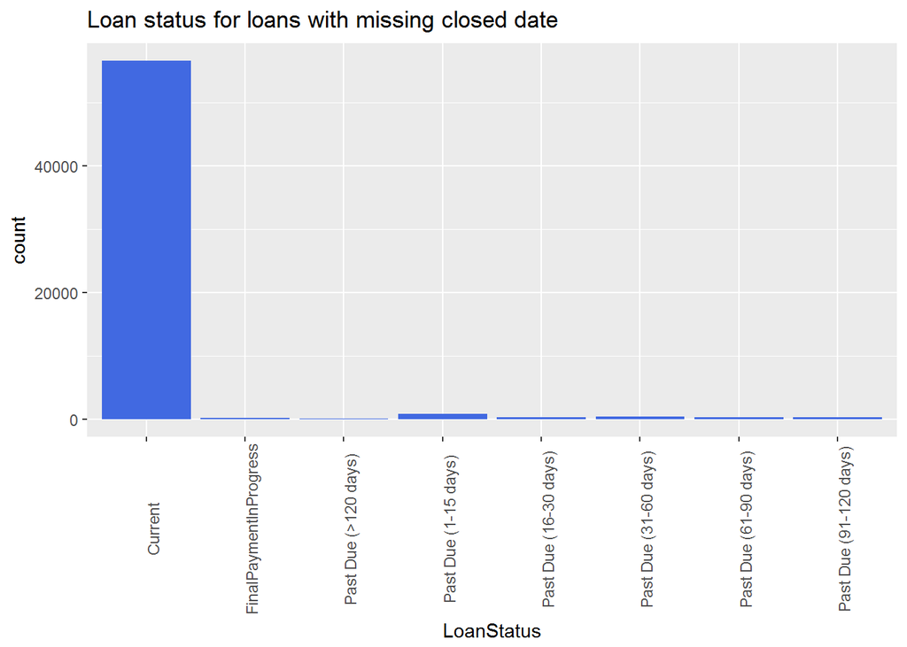

Many other missing values are connected to the date of origination, because the amount of data collected changed during time.

`EmploymentStatusDuration` is missing in before 2008.

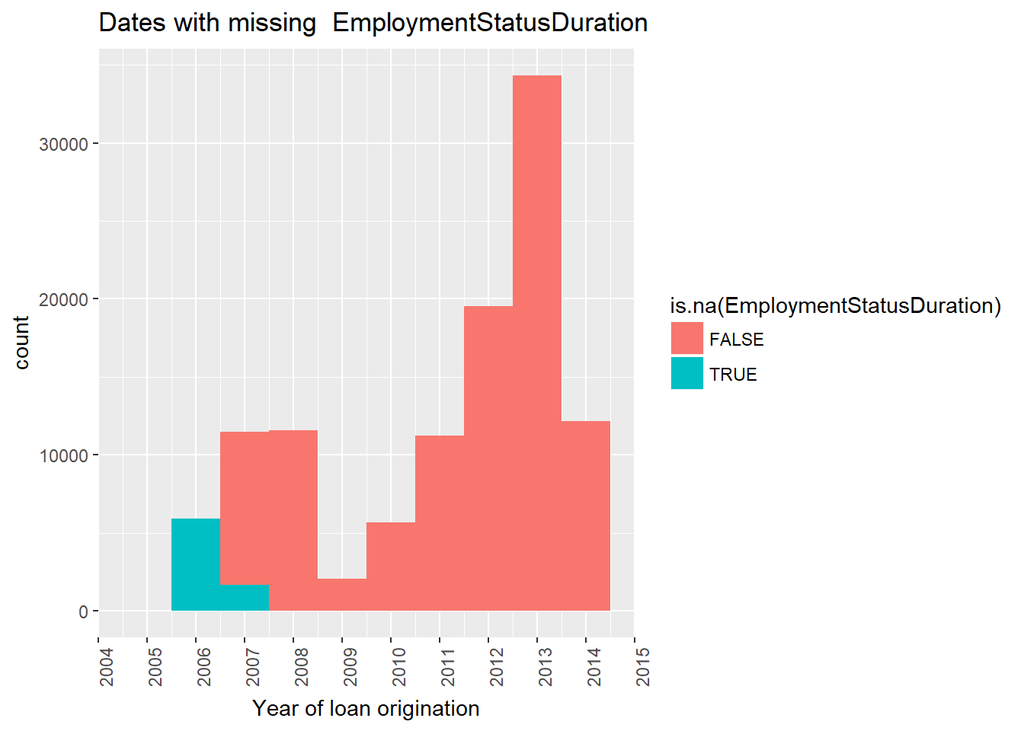

`CreditScoreRangeLower` is missing for few loans originated prior to 2007.

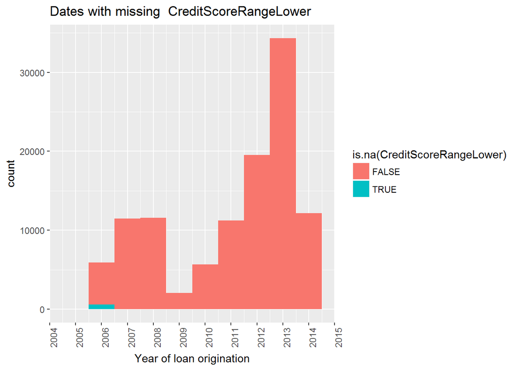

`FirstRecordedCreditLine` is missing for some loans originated in 2006.

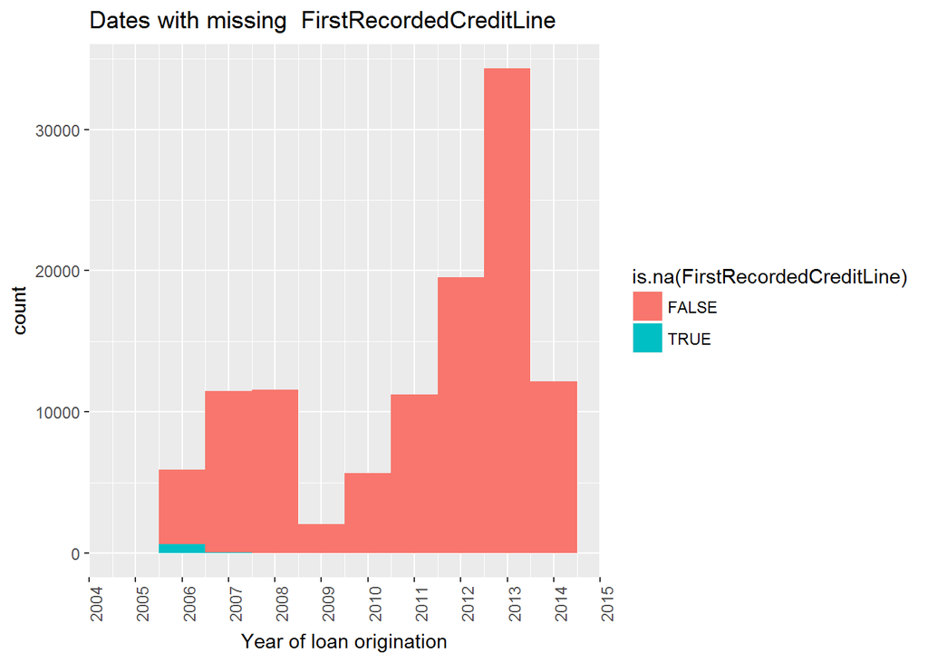

`CurrentCreditLines` is missing for loans originated in 2006 and for some originated in 2007.

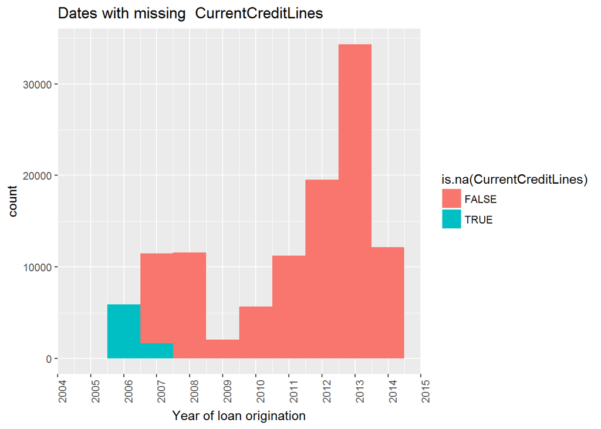

`TotalInquiries` is missing for some loans originated in 2006.

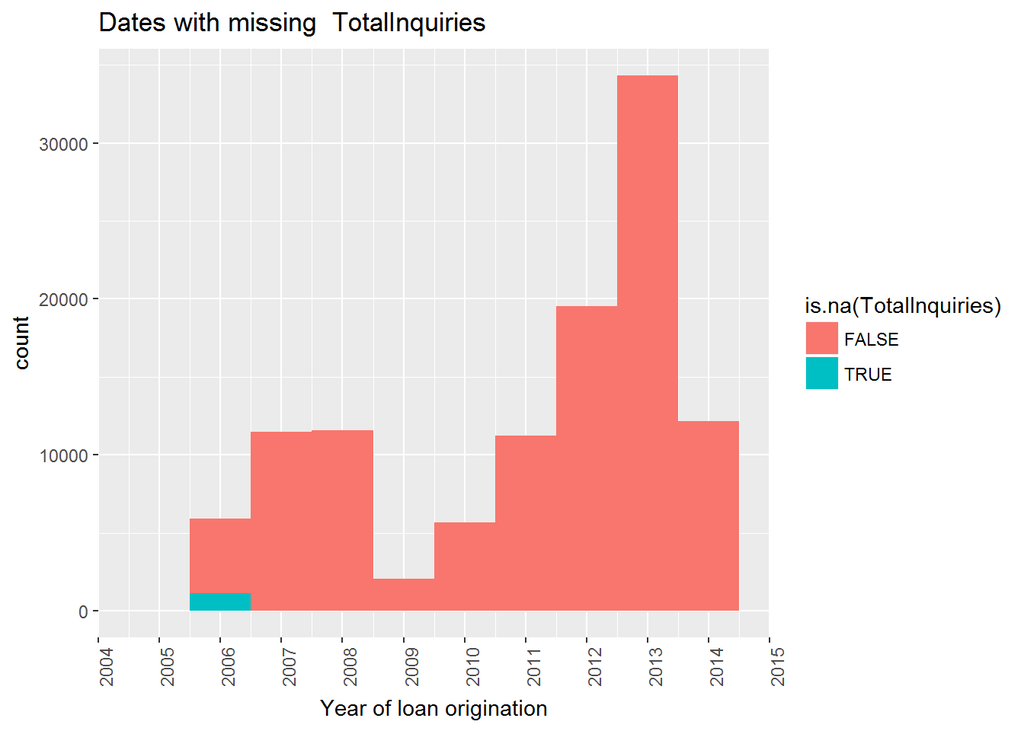

`AmountDelinquent` is missing for loans originated in 2006 and for some originated in 2007.

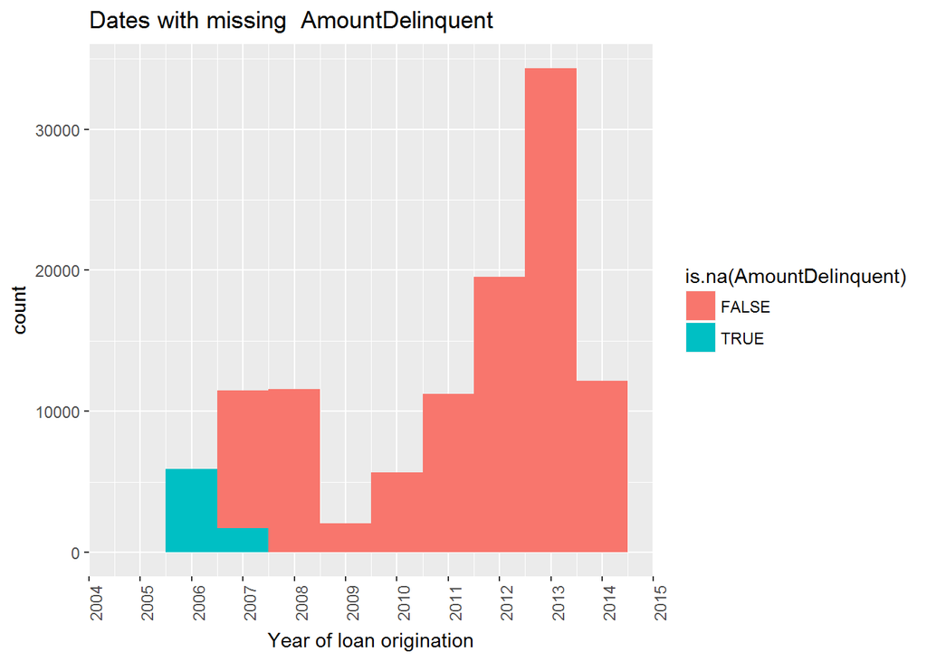

`TotalProsperLoans` is missing for loans for which the borrower does not have previous Prosper loans.

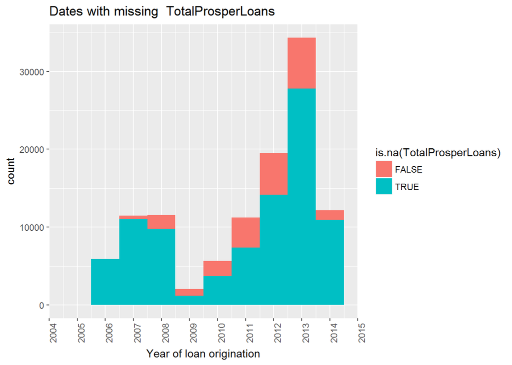

`FirstRecordedCreditLine` is missing for some loans originated in 2006.

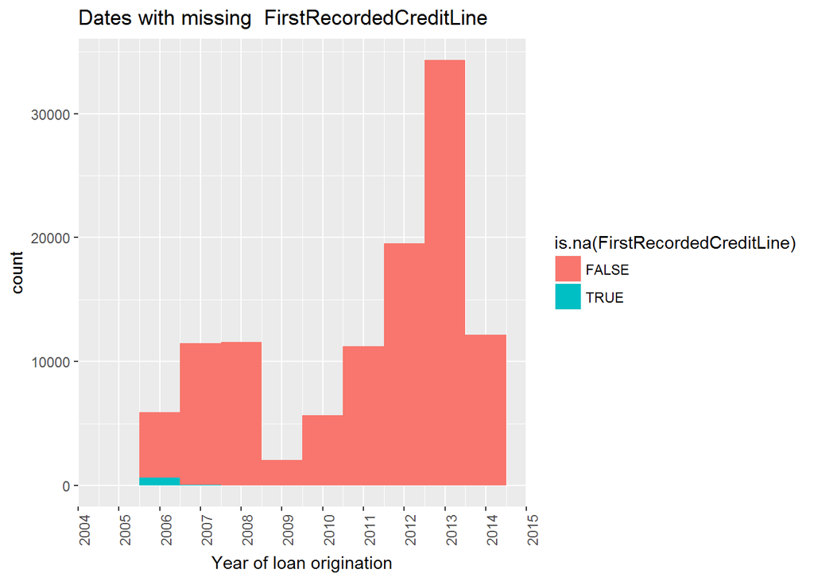

`BankcardUtilization` is missing for loans in 2006 and for few loans in 2007.

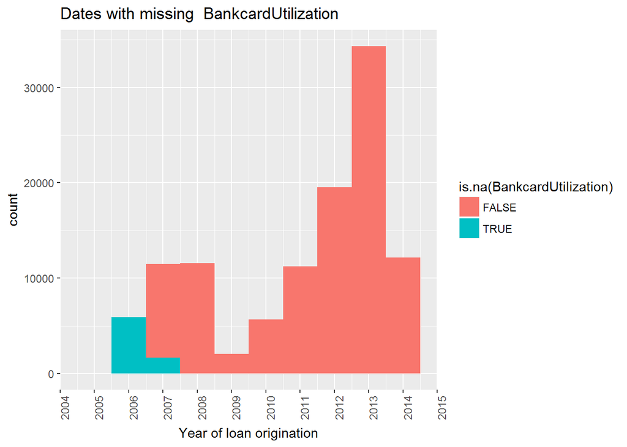

To obtain a clean subset of data, entries with missing values for `EmploymentStatusDuration`, `ClosedDate`, `FirstRecordedCreditLine` and `BankcardUtilization` are removed. Because a closing date is required there will be only closed loans in the resulting data set.

The following table shows fields that still include missing values.

```
##                             ColumnName NumberMissingValues
## 4                          CreditGrade               26127
## 11             EstimatedEffectiveYield               21456
## 12                       EstimatedLoss               21456
## 13                     EstimatedReturn               21456
## 14             ProsperRating..numeric.               21456
## 15               ProsperRating..Alpha.               21456
## 16                        ProsperScore               21456
## 47                   DebtToIncomeRatio                4080
## 52                   TotalProsperLoans               36915
## 53          TotalProsperPaymentsBilled               36915
## 54               OnTimeProsperPayments               36915
## 55 ProsperPaymentsLessThanOneMonthLate               36915
## 56     ProsperPaymentsOneMonthPlusLate               36915
## 57            ProsperPrincipalBorrowed               36915
## 58         ProsperPrincipalOutstanding               36915
## 59         ScorexChangeAtTimeOfListing               37012
## 61       LoanFirstDefaultedCycleNumber               33618
```

Fields related to previous Prosper loans are missing, if the borrower has no previous Prosper loans, according to the [documentation](https://www.google.com/url?q=https://docs.google.com/spreadsheets/d/1gDyi_L4UvIrLTEC6Wri5nbaMmkGmLQBk-Yx3z0XDEtI/edit?usp%3Dsharing&sa=D&ust=1496705059891000&usg=AFQjCNHMPfI22Q3BdA7io-Z1-maqjiIT7Q). These fields are set to 0 in cases where they are missing for further analyses. Other columns with missing values will be ignored through the rest of this project. The are no further columns with missing entries:

```
## [1] ColumnName          NumberMissingValues
## <0 rows> (or 0-length row.names)
```

# Univariate analysis

Most of the loans are completed. Some a charged off or defaulted. Since both states result in a loss for Prosper I will take flag loans as bad, if they either defaulted or have been charged off. The single cancelled loan is removed from the data set.

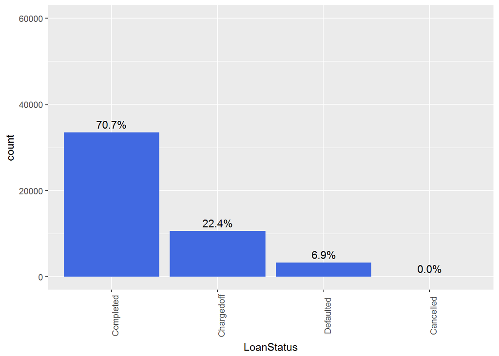

There is a gap in loan origination dates.

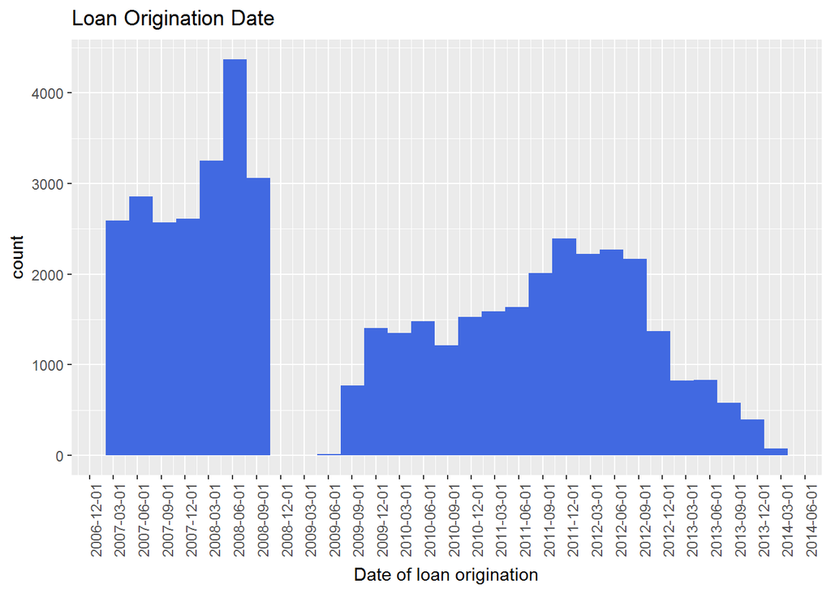

# Uni- and Multivariate

Now, uni-variate and multi-variate distributions and correlations are analyzed for changing subsets of the borrower related variables, since it is not practical to put all 35 variables in a scatter plot matrix. Variables in a subsets are related to specific properties of borrowers.

## Borrower’s life circumstances

`EmploymentStatus`, `EmploymentStatusDuration`, `IsBorrowerHomeowner`,`IncomeVerifiable`, `StatedMonthlyIncome`, `DebtToIncomeRatio`, `Occupotion` and `BorrowerState` are regarded as variables connected to the life circumstances of the respective borrower. `Occupotion` and `BorrowerState` are omitted since these categorical features have too many levels for an interpretable two-variable analysis. None of the investigated variables for the borrower’s life circumstances show strong correlations. The plot shows in red completed loans, defaulted loans in blue and charged off loans in green.

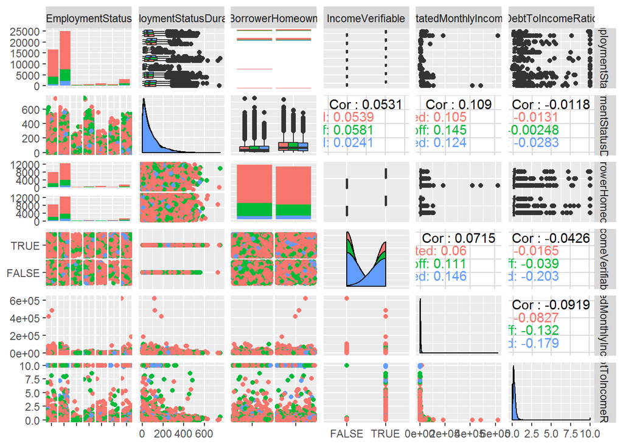

The median stated monthly income is $4250. There are many loans where borrower’s stated monthly incomes of 0 that are not verifiable.

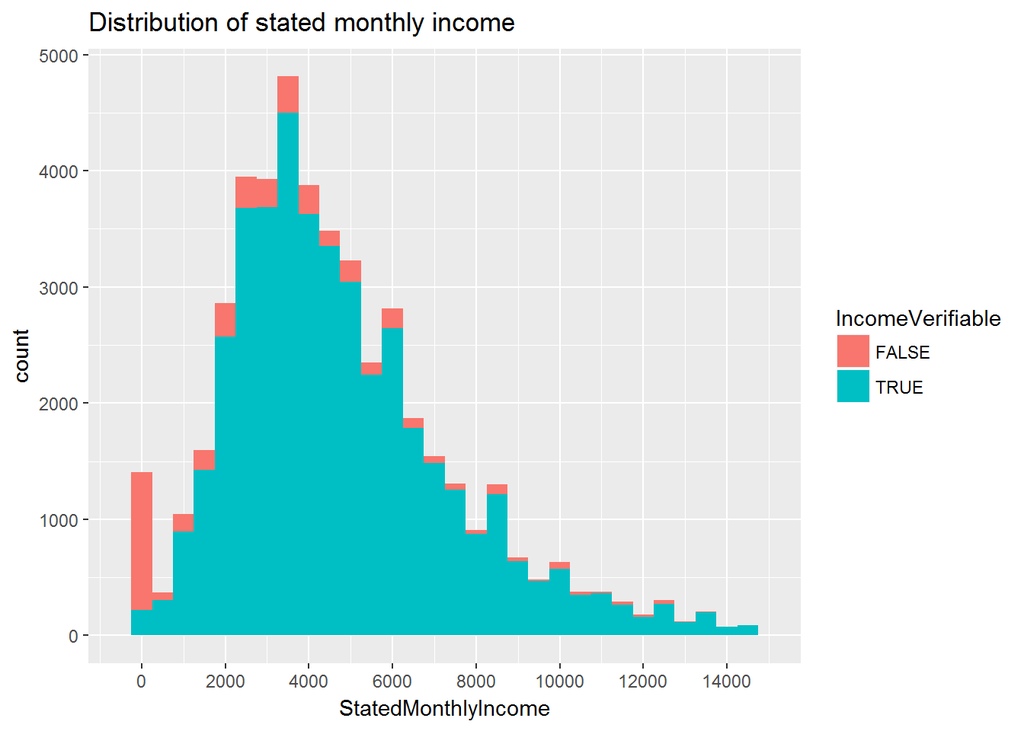

```
##    Min. 1st Qu.  Median    Mean 3rd Qu.    Max.
##       0    2893    4250    5107    6250  618548
```

Investors have the highest verifiable mean monthly income (green dashed line).

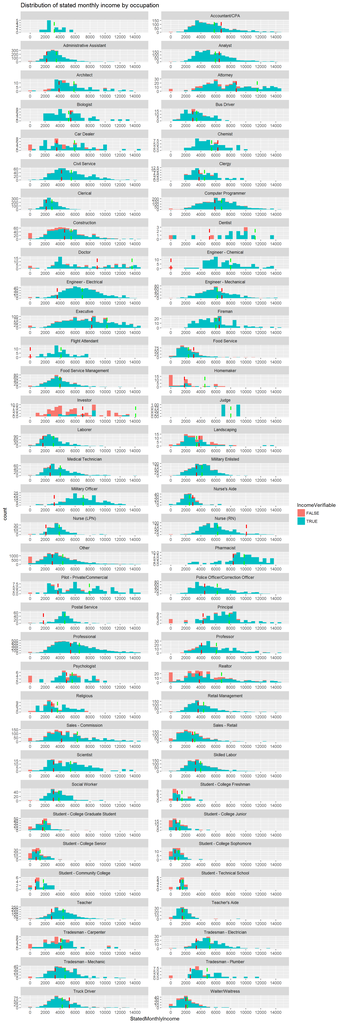

## Credit score

`CreditScoreRangeLower` and `CreditScoreRangeUpper` can be derived from each other. Therefore, `CreditScoreRangeUpper` is removed from the data set, since is does not provide additional information over `CreditScoreRangeLower`.

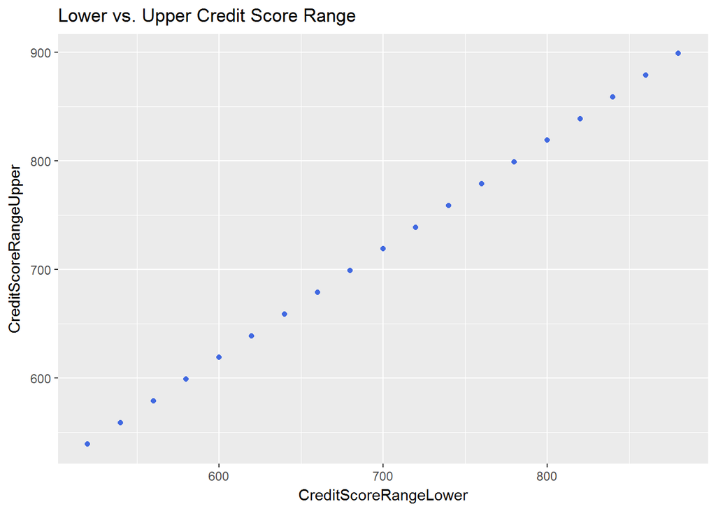

## Credit lines

Credit line related features are `FirstRecordedCreditLine`, `CurrentCreditLines` and `TotalCreditLinespast7years`.

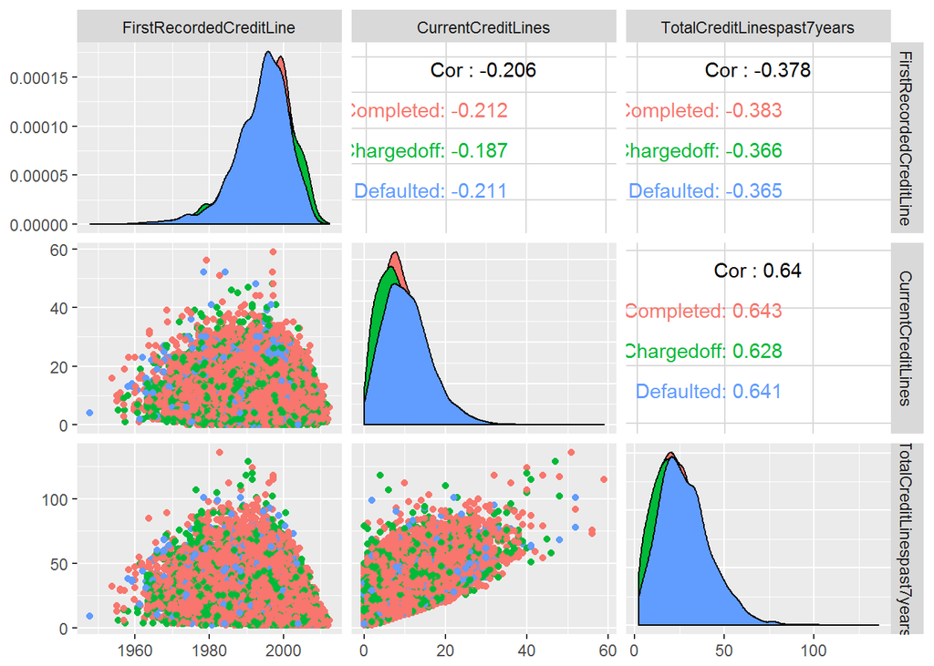

First recorded credit line is anti-correlated to the other two features. The earlier a customer obtained a credit line the more credit lines he has or had. Naturally, current credit line and total credit lines in past seven years are correlated. The number of total credit lines in the past seven years are at least the number of current credit lines. A new variable, `TotalClosedCreditLinesPast7years` is calculated as the difference between the number of total credit lines in the past seven years, `TotalCreditLinespast7years` and the number of current credit lines, `CurrentCreditLines`. The correlation of `CurrentCreditLines` and `TotalClosedCreditLinesPast7years` is half the correlation of `CurrentCreditLines` and `TotalCreditLinespast7years`.

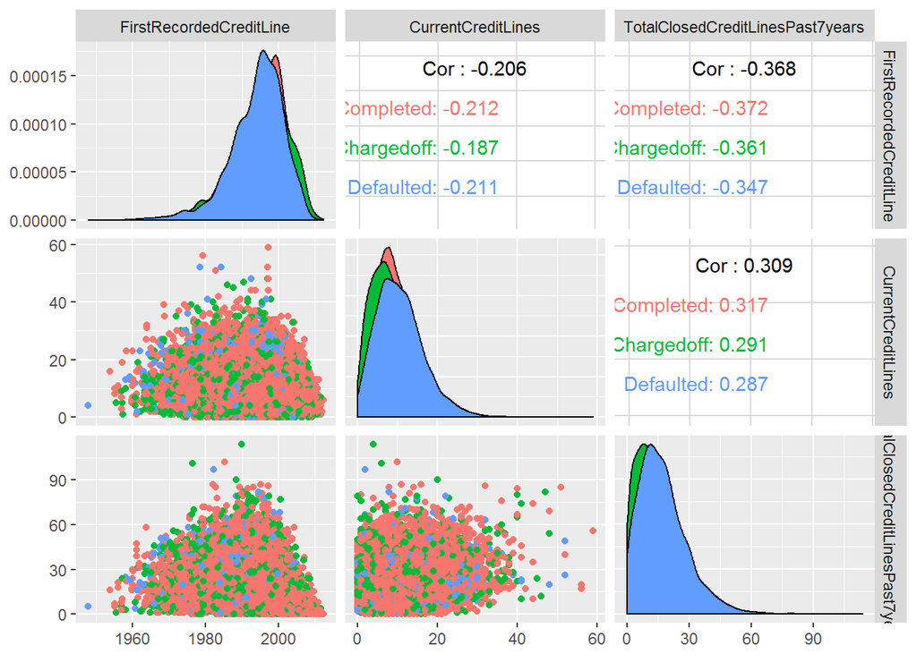

## Revolving accounts

`OpenRevolvingAccounts`, `OpenRevolvingMonthlyPayment`, `RevolvingCreditBalance` `BankcardUtilization` and `AvailableBankcardCredit` are variables related to credit card accounts.

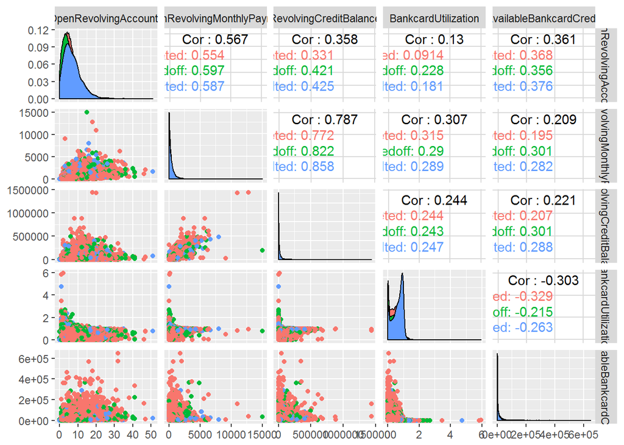

Defaulted loans tend to have higher monthly payments for open revolving credits.

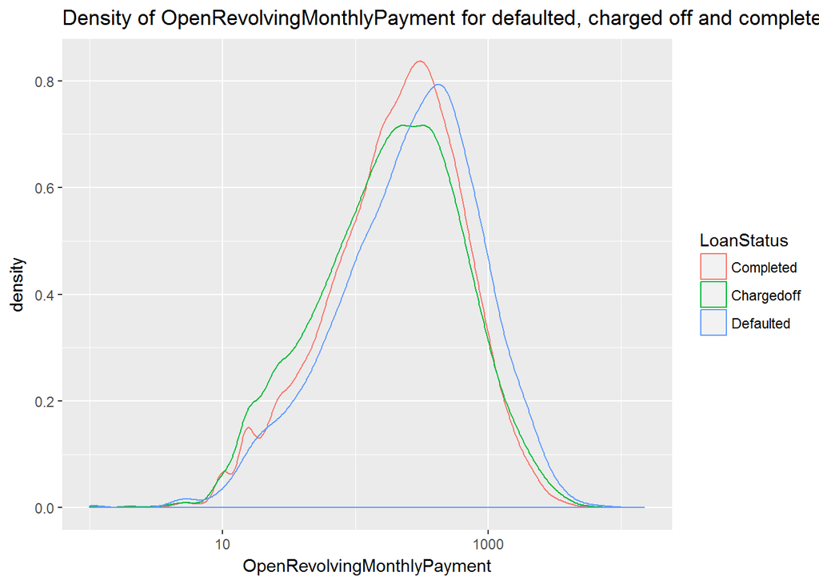

The correlation between `RevolvingCreditBalance` and `OpenRevolvingMonthlyPayment` becomes obvious when switching to a logarithmic scale for both variables and plotting the binned median revolving credit balance versus the open monthly payments for revolving credits. The correlation on the logarithmic scale is .86.

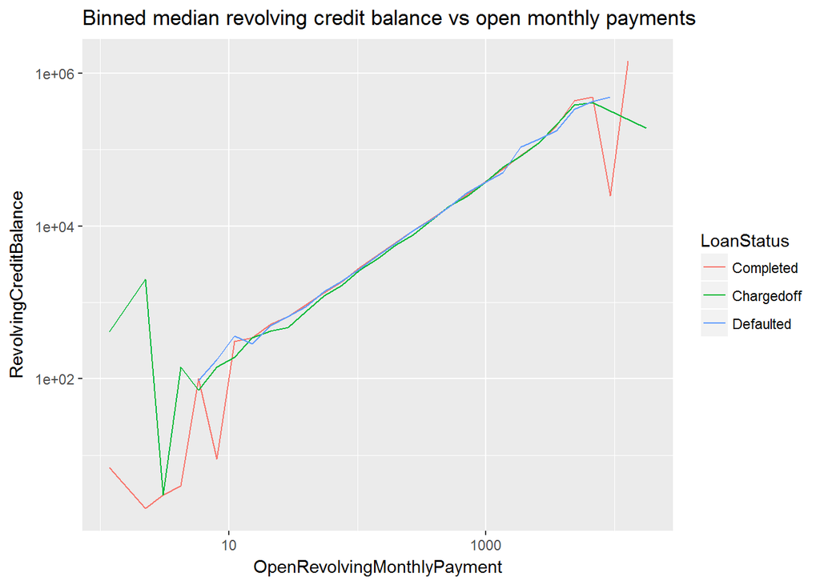

```
## [1] 0.8644777
```

The utilization of bank card revolving credits is bi-modal with peaks at 0 and 100%. In cases of defaulted and charged-off loans the peak at 0 is smaller and higher at 100%.

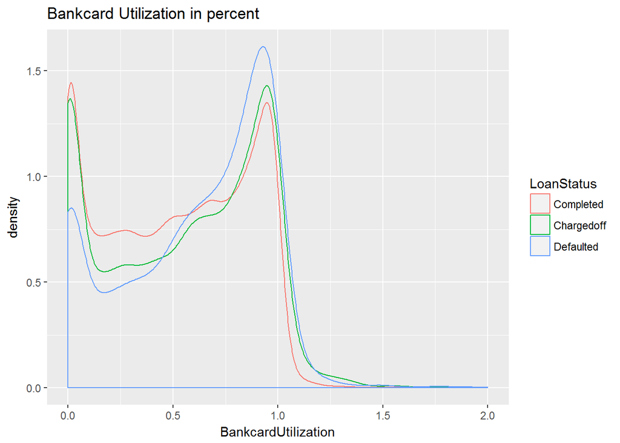

Borrower that completed the repayment of the loan have slightly higher bank card credits.

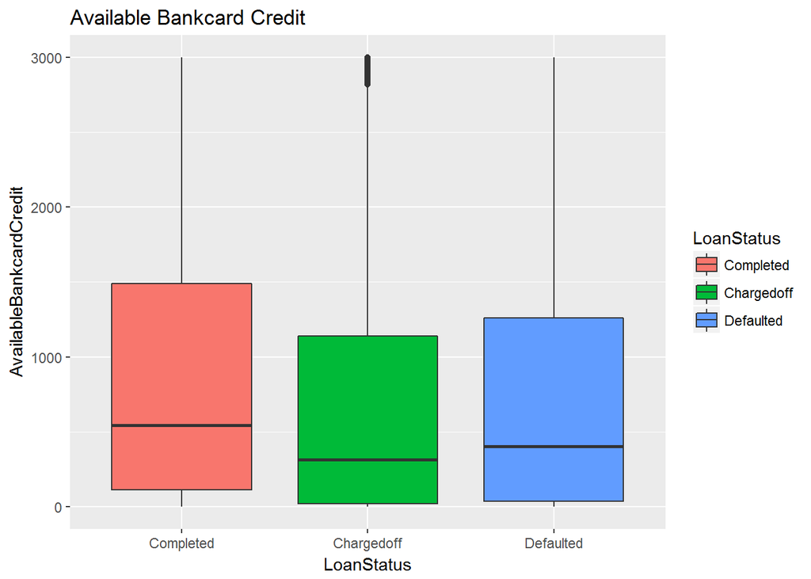

## Inquiries related features.

`InquiriesLast6Months` and `TotalInquiries` are inquiries related features.

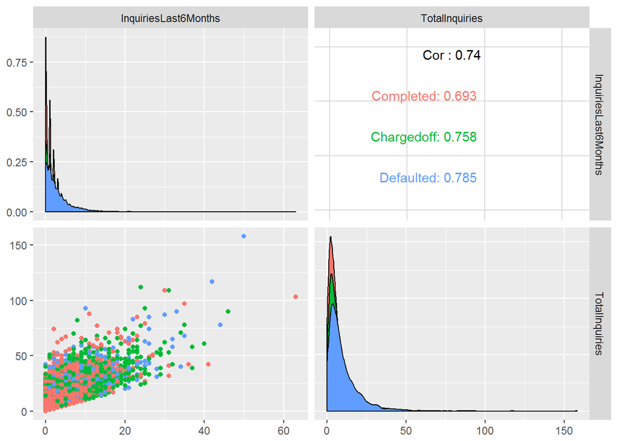

To decorrelate `InquiriesLast6Months` and `TotalInquiries` a new variable `InquiriesBefore6Months` is calculated as the difference between `TotalInquiries` and `InquiriesLast6Months`. The correlation decreases from .74 to .47.

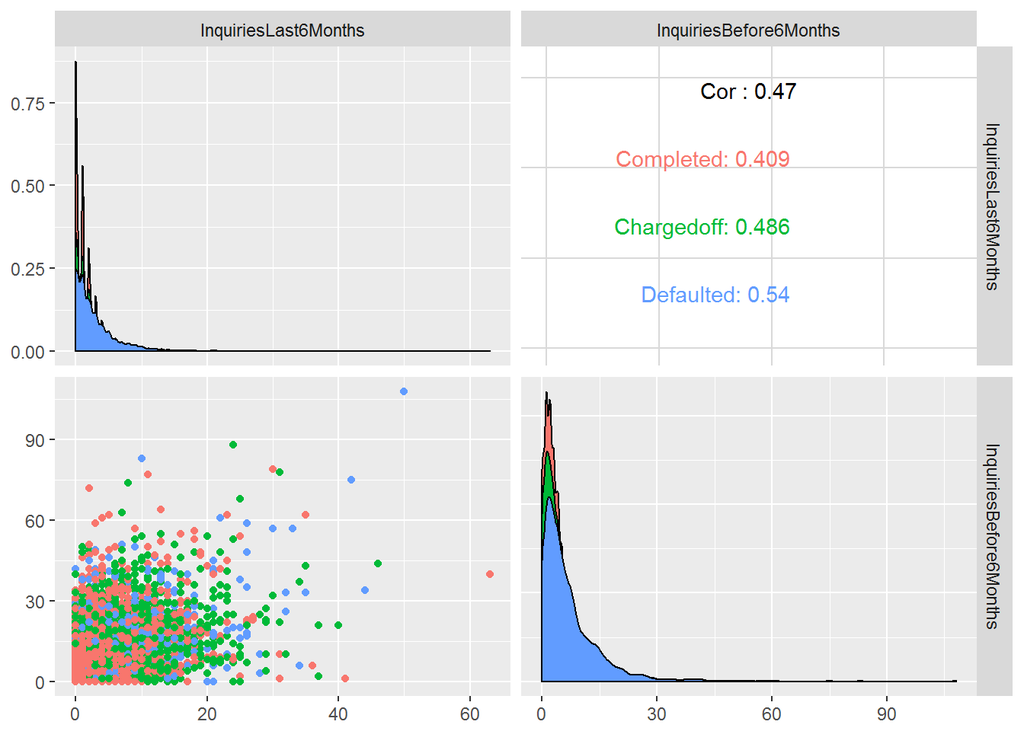

Defaulted loans tend to have more inquiries in the last 6 month.

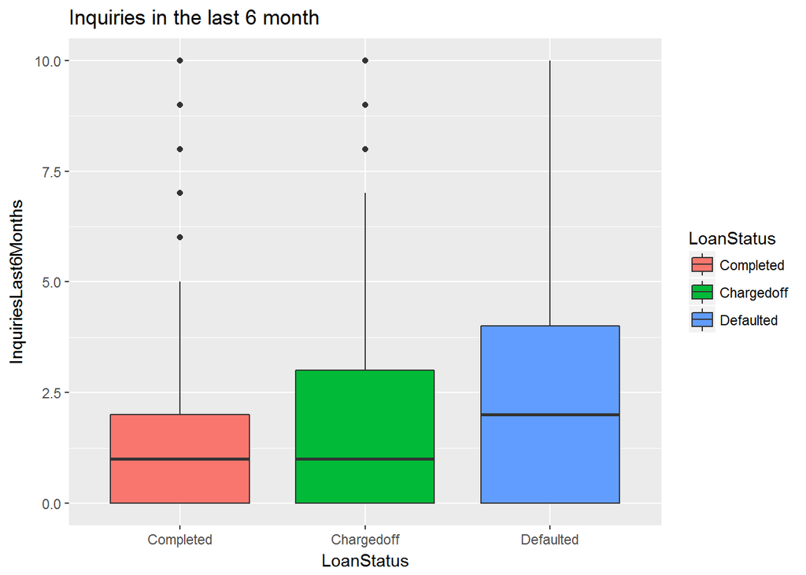

## Delinquencies related features

Delinquencies related features are `AmountDelinquent`, `CurrentDelinquencies` and `DelinquenciesLast7Years`.

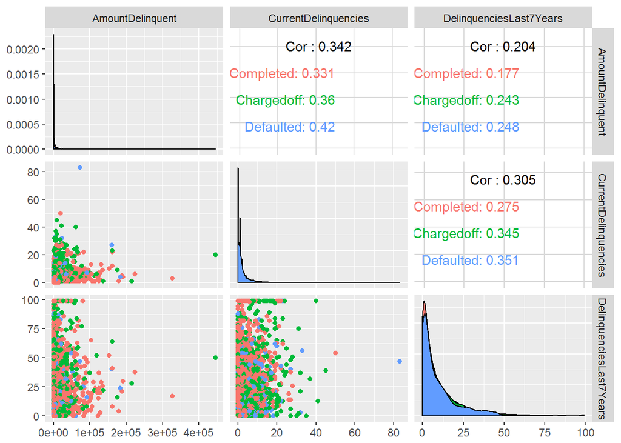

Most of the loans have zero amount delinquent, 84% for completed loans, 71% for charged off loans and 74% for defaulted loans. The distribution of delinquent amounts is comparable for all three investigated loan status.

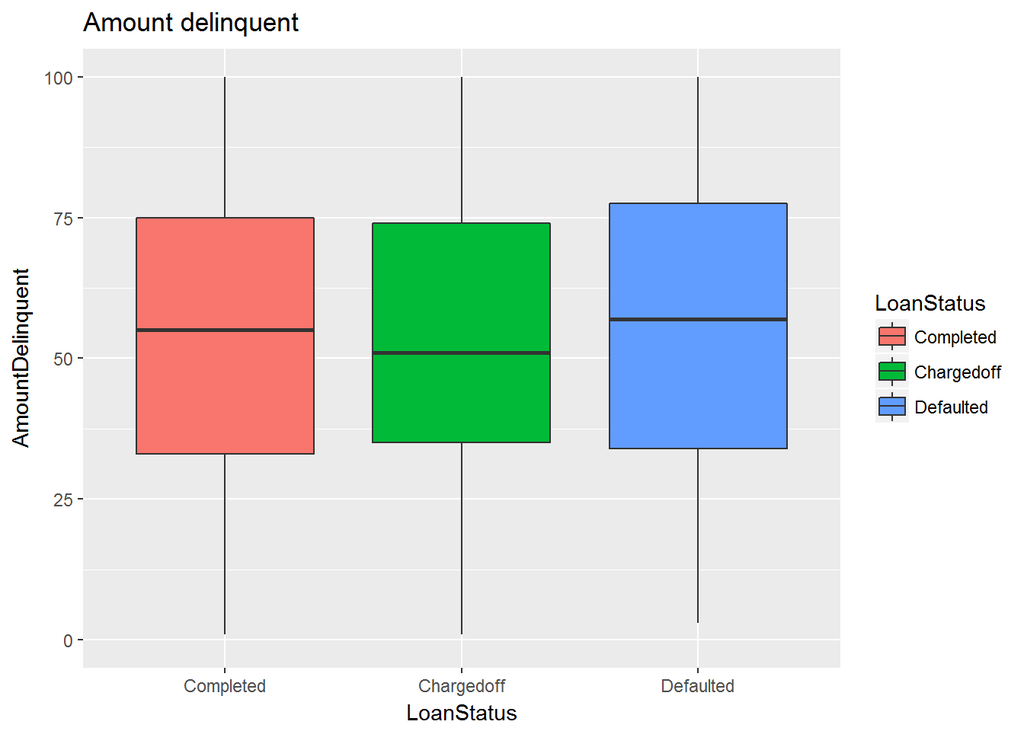

```
## # A tibble: 3 x 3
##   LoanStatus      mean Percent_Zero_Amount
##       <fctr>     <dbl>               <dbl>
## 1  Completed  895.6284           0.8416045
## 2 Chargedoff 1492.9602           0.7134123
## 3  Defaulted 1206.4062           0.7476437
```

The median number of current delinquencies is a higher for charged off and defaulted loans.

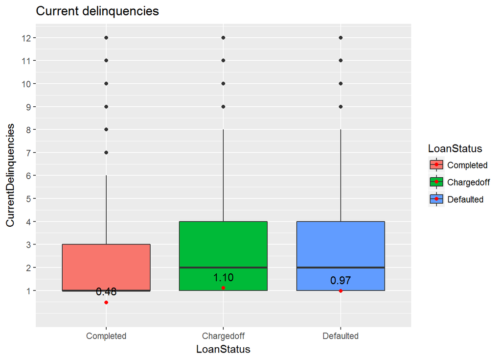

The distributions significantly differ as ANOVA reveals.

```
##                Df Sum Sq Mean Sq F value Pr(>F)
## LoanStatus      2   3507    1753   438.8 <2e-16 ***
## Residuals   47448 189599       4
## ---
## Signif. codes:  0 '***' 0.001 '**' 0.01 '*' 0.05 '.' 0.1 ' ' 1
```

```
##                          2.5 %    97.5 %
## (Intercept)          0.4542070 0.4970008
## LoanStatusChargedoff 0.5805810 0.6677973
## LoanStatusDefaulted  0.4224012 0.5655821
```

# Trade related variables

Trade related variables are `TotalTrades`, `TradesNeverDelinquent..percentage.` and `TradesOpenedLast6Months`.

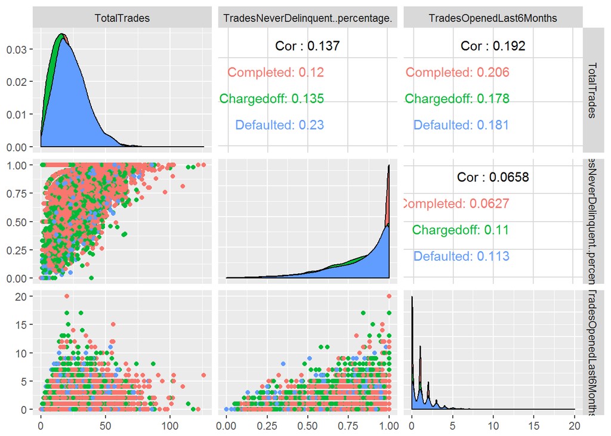

# Prosper loan related features

Prosper loan related features are `TotalProsperLoans`, `TotalProsperPaymentsBilled`, `OnTimeProsperPayments`, `ProsperPaymentsLessThanOneMonthLate`, `ProsperPaymentsOneMonthPlusLate`, `ProsperPrincipalBorrowed` and `ProsperPrincipalOutstanding`. Since the number of on time Prosper payments is limited to the number of billed Prosper payments, the variables `TotalProsperPaymentsBilled` and `OnTimeProsperPayments` are strongly correlated.

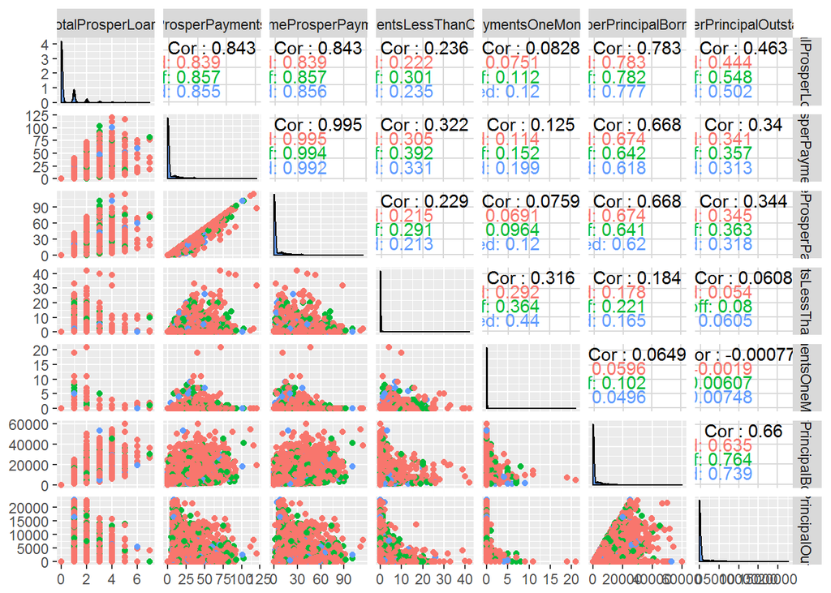

A new variable `OverdueProsperPaymentsPercent` is calculated as the difference of `TotalProsperPaymentsBilled` and `OnTimeProsperPayments` relative to `TotalProsperPaymentsBilled`. The correlation can be reduced to .07 performing this transformation.

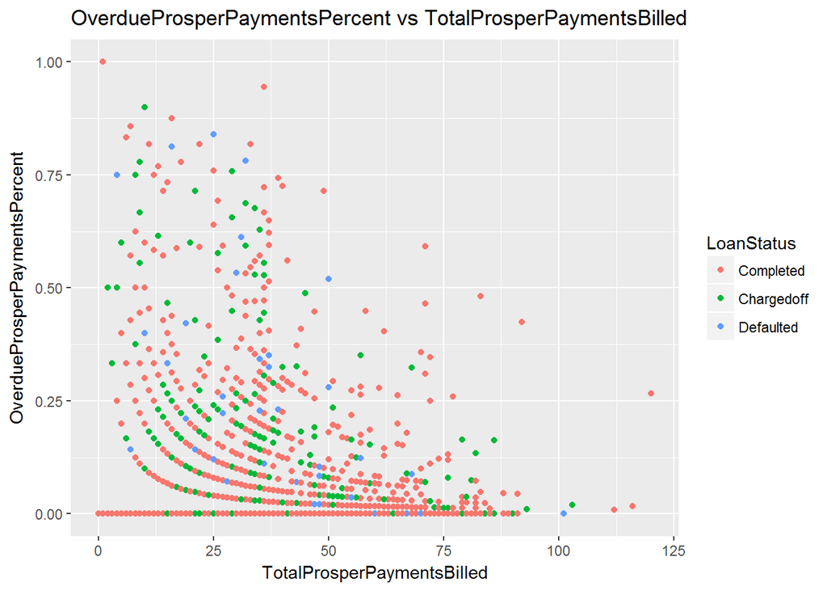

```
## [1] 0.07497828
```